# Лабораторная работа №01

Компьютерный практикум по статистическому анализу данных

Ибрахим Мохсейн Алькамаль

1032225432@rudn.ru

Российский университет дружбы народов

2026-09-12

# Информация

## Докладчик

- Ибрахим Мохсейн Алькамаль
- Российский университет дружбы народов

# Цель работы

- Освоить основные возможности языка Julia.
- Изучить работу в интерактивной среде и JupyterLab.
- Рассмотреть типы данных, ввод и вывод, арифметические и логические операции.
- Освоить создание функций и базовые операции с векторами и матрицами.

# Выполнение лабораторной работы

## Подготовка рабочей директории и репозитория

- Создана рабочая директория для курса.
- Клонирован репозиторий `computer-practice` вместе с подмодулями.

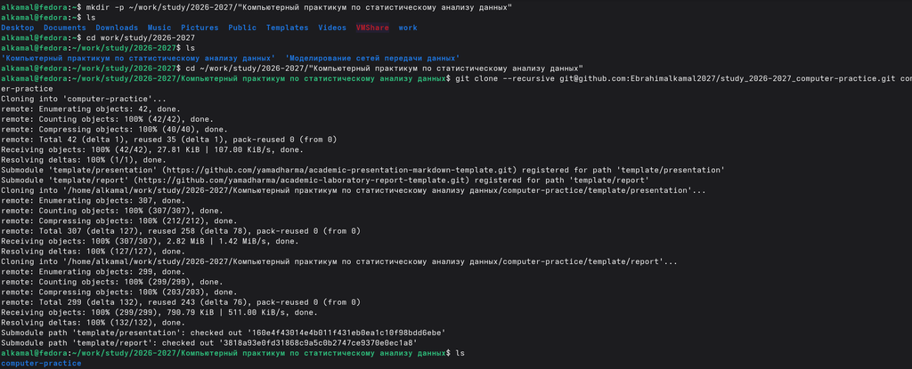

Рисунок 1: Создание рабочей директории и клонирование репозитория курса

## Подготовка структуры лабораторных работ

- Просмотрены доступные цели `make` и учебные курсы.
- Подготовлена структура курса `computer-practice`.
- Созданы каталоги `lab01`–`lab08`.

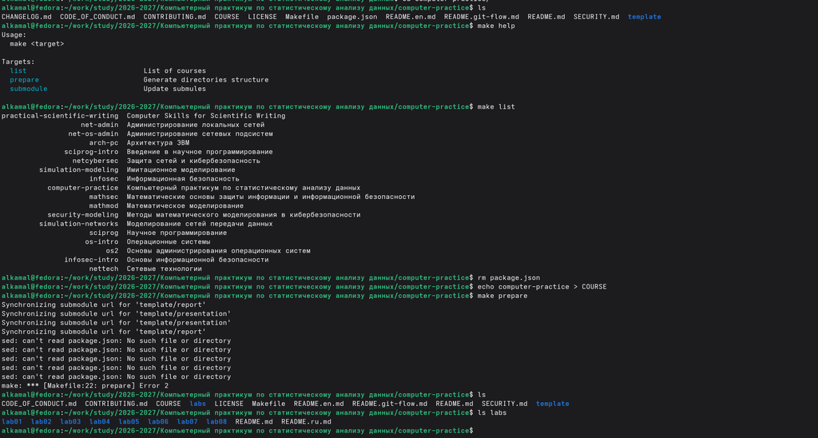

Рисунок 2: Подготовка структуры каталогов лабораторных работ

## Настройка Git

- Добавлен удалённый репозиторий `gitverse`.
- Проверена конфигурация удалённых репозиториев.
- Изменения зафиксированы сообщением `feat(main): make course structure`.

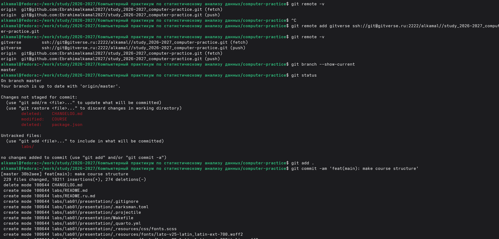

Рисунок 3: Настройка удалённого репозитория и фиксация структуры проекта в Git

## Проверка программного окружения

- Julia: версия `1.12.1`.
- JupyterLab: версия `4.6.3`.
- Проверены версии основных компонентов Jupyter.

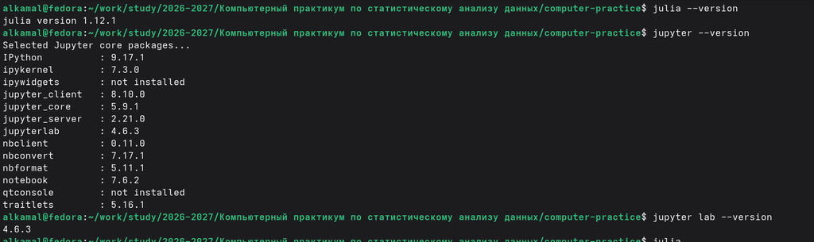

Рисунок 4: Проверка версий Julia и компонентов Jupyter

## Запуск Julia REPL

- Запущена интерактивная среда Julia REPL.
- Отображена версия Julia `1.12.1`.
- Для ввода команд используется приглашение `julia>`.

[figure not shown]

Рисунок 5: Запуск интерактивной среды Julia REPL

## Установка IJulia

- Установлен пакет `IJulia`.
- Автоматически добавлены необходимые зависимости.
- Выполнена предварительная компиляция.

[figure not shown]

Рисунок 6: Установка пакета IJulia и его зависимостей

## Запуск Jupyter Notebook

- Проверен список доступных ядер Jupyter.
- Доступны ядра `julia-1.12` и `python3`.
- Запущен локальный сервер Jupyter на порту `8888`.

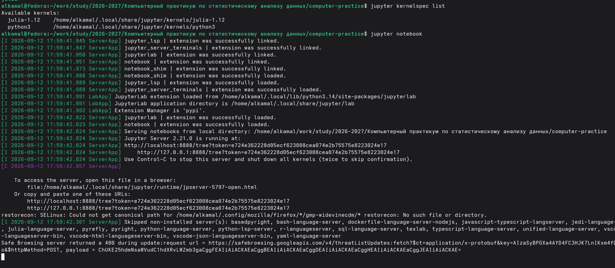

Рисунок 7: Проверка ядра Julia и запуск сервера Jupyter Notebook

## Интерфейс Jupyter

- Открыт интерфейс Jupyter в браузере.
- Отображены каталоги `labs`, `template` и файлы репозитория.

[figure not shown]

Рисунок 8: Интерфейс Jupyter с содержимым рабочей директории проекта

## Запуск JupyterLab

- Выполнена команда `jupyter lab`.
- Компоненты JupyterLab успешно загружены.
- Локальный сервер работает на порту `8888`.

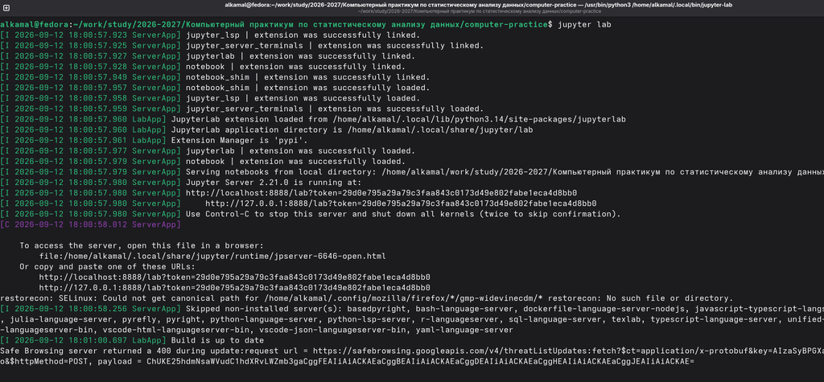

Рисунок 9: Запуск локального сервера JupyterLab

## Ядро Julia в JupyterLab

- В Launcher доступны различные среды выполнения.
- Доступно ядро `Julia 1.12`.
- Можно создавать Notebook и консоль с Julia.

[figure not shown]

Рисунок 10: Интерфейс JupyterLab с доступным ядром Julia 1.12

## Создание Notebook

- Создан новый Notebook.
- Выбрано ядро `Julia 1.12`.
- Команды Julia выполняются в ячейках JupyterLab.

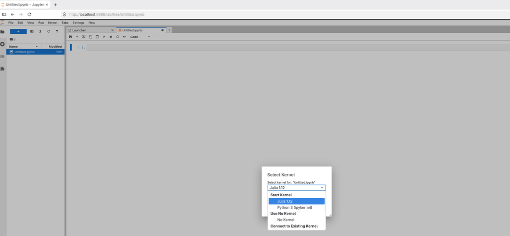

Рисунок 11: Выбор ядра Julia 1.12 для нового Jupyter Notebook

## Арифметические операции и справка

- Выполнены простейшие арифметические операции.
- Получены результаты вычислений.
- Командой `?println` открыта документация функции `println`.

[figure not shown]

Рисунок 12: Выполнение арифметических операций и просмотр справки Julia

## Системные команды

- Выполнена команда `;date`.
- Выполнена команда `;whoami`.
- Выведены дата, время и имя пользователя системы.

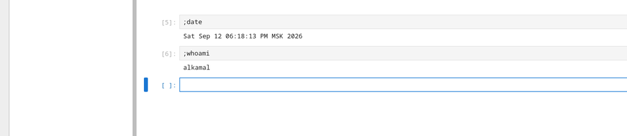

Рисунок 13: Выполнение системных команд date и whoami в Jupyter Notebook

## Числовые типы Julia

- Исследованы типы данных с помощью `typeof`.
- Рассмотрены целые, вещественные, комплексные и иррациональные значения.
- Проверены `Inf`, `-Inf`, `NaN` и диапазоны целочисленных типов.
- Выполнены преобразование и продвижение типов.

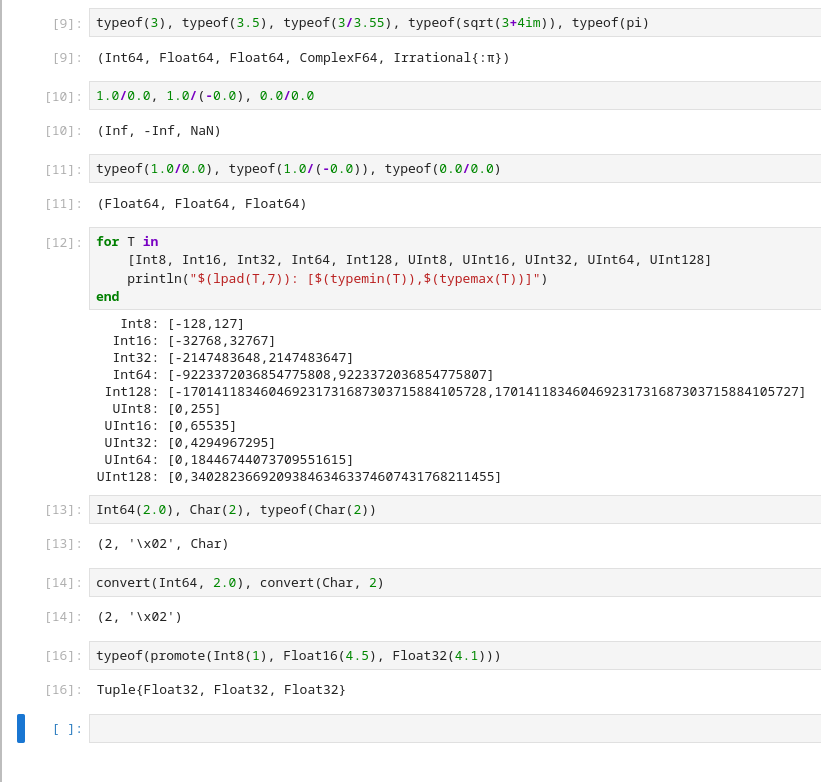

Рисунок 14: Исследование числовых типов и преобразований данных в Julia

## Создание функций

- Функция `f(x)` задана конструкцией `function ... end`.
- Функция `g(x)` задана краткой записью.
- Для аргументов `4` и `8` получены результаты `16` и `64`.

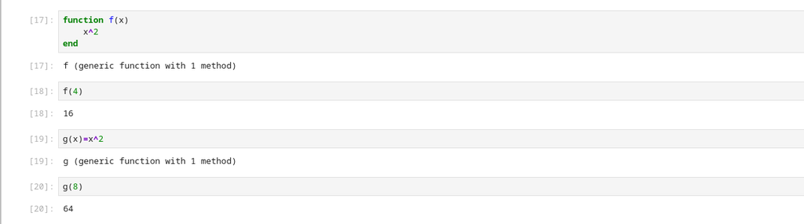

Рисунок 15: Определение и вызов функций в Julia

## Массивы и матрицы

- Рассмотрено создание массивов и матриц.
- Выполнено обращение к элементам по индексам.
- Создана матрица размером `2×2`.
- Выполнено матричное выражение с результатом `27`.

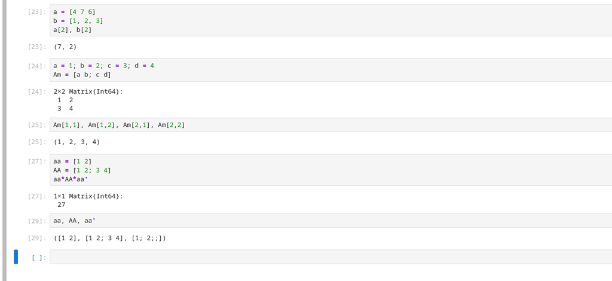

Рисунок 16: Работа с массивами, матрицами и индексами в Julia

# Задания для самостоятельной работы

## Функции ввода и вывода

- Рассмотрены `print()`, `println()` и `show()`.
- `write()` использована для записи в `example.txt`.
- `read()` использована для чтения содержимого файла.

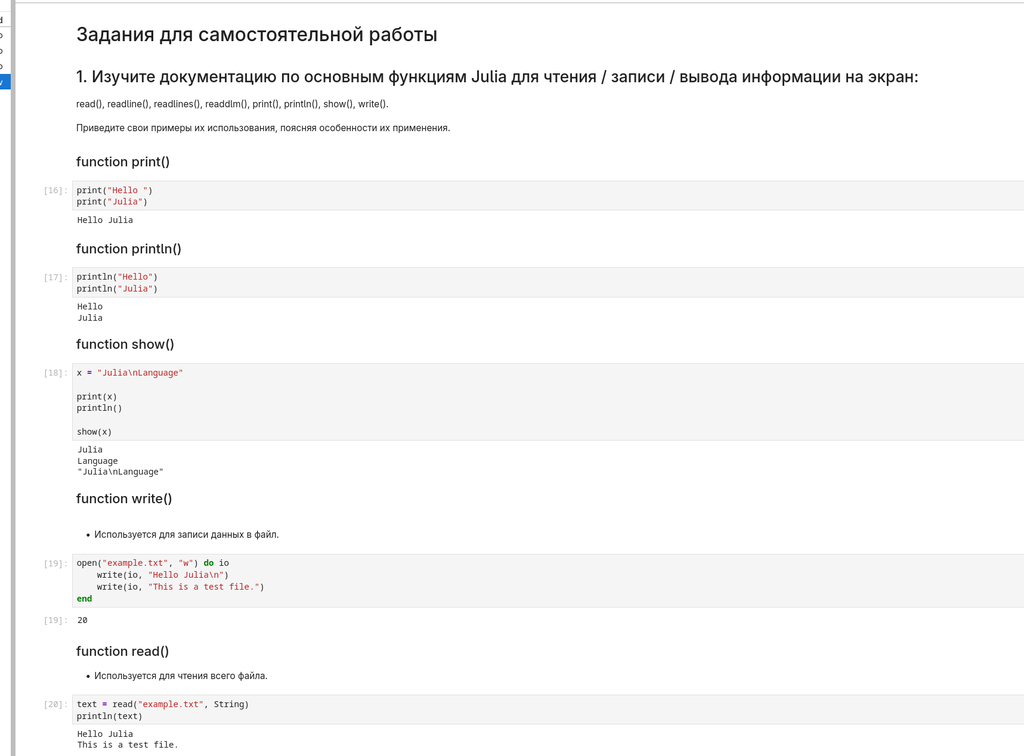

Рисунок 17: Использование функций вывода, записи и чтения данных в Julia

## Чтение данных из файлов

- `readline()` считывает одну строку.
- `readlines()` возвращает строки файла в виде массива.
- `readdlm()` считывает числовые данные из `data.txt` в виде матрицы.

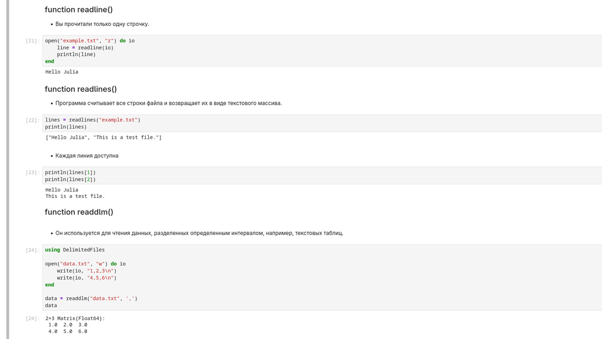

Рисунок 18: Чтение строк и табличных данных из файлов в Julia

## Функция parse()

- `parse()` преобразует строковые значения в заданный тип.
- `"123"` преобразовано в `Int64`.
- `"3.1415"` преобразовано в `Float64`.
- `"1010"` в системе счисления с основанием `2` преобразовано в `10`.

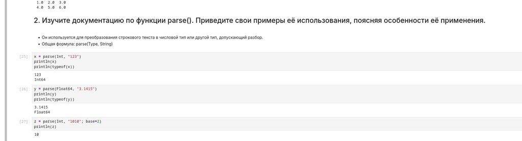

Рисунок 19: Примеры преобразования строковых данных функцией parse

## Базовые арифметические операции

- Заданы переменные разных числовых типов.
- Выполнены сложение, вычитание и умножение.
- Выполнено обычное деление.
- Рассмотрены `div()` и `rem()`.

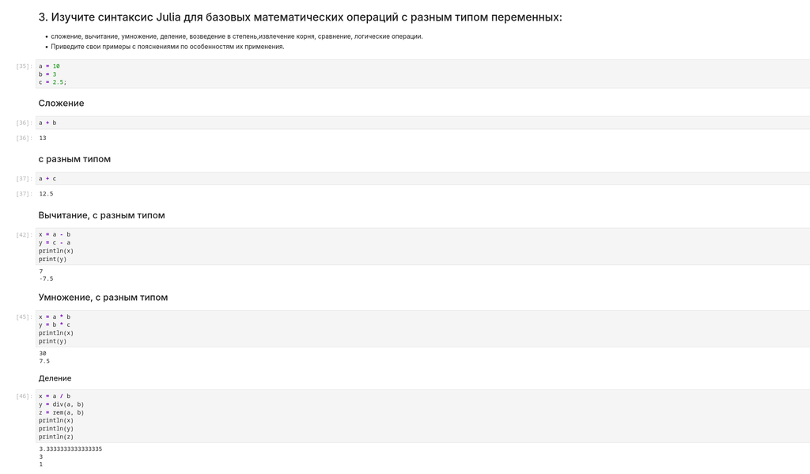

Рисунок 20: Выполнение базовых арифметических операций с числовыми переменными

## Степень, сравнение и логические операции

- Выполнено возведение в степень.
- Выполнено извлечение квадратного корня.
- Рассмотрены операции `>`, `<`, `==`, `!=`.
- Выполнены логические операции `&&`, `||`, `!`.

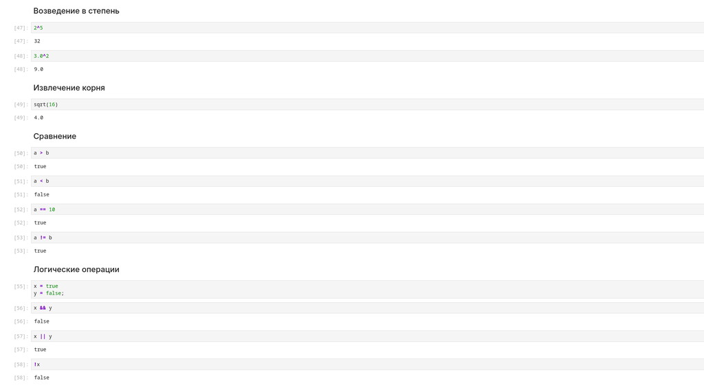

Рисунок 21: Выполнение операций возведения в степень, сравнения и логических операций

## Операции над векторами

- Созданы векторы `v1` и `v2`.
- Выполнены сложение и вычитание.
- Скалярное произведение вычислено с помощью `dot()`.
- Выполнены транспонирование и умножение на скаляр.

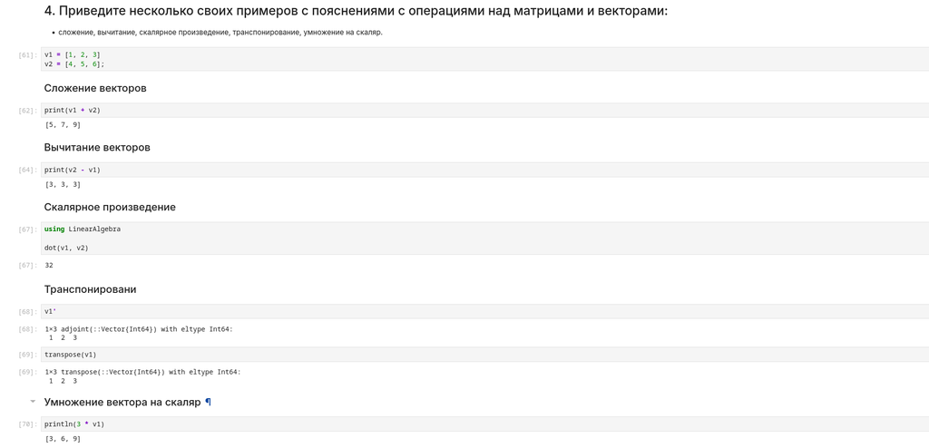

Рисунок 22: Выполнение основных операций над векторами в Julia

## Операции над матрицами

- Созданы матрицы `A` и `B` размером `2×2`.
- Выполнены сложение и вычитание.
- Выполнено транспонирование матрицы `A`.
- Матрица `A` умножена на скаляр `2`.

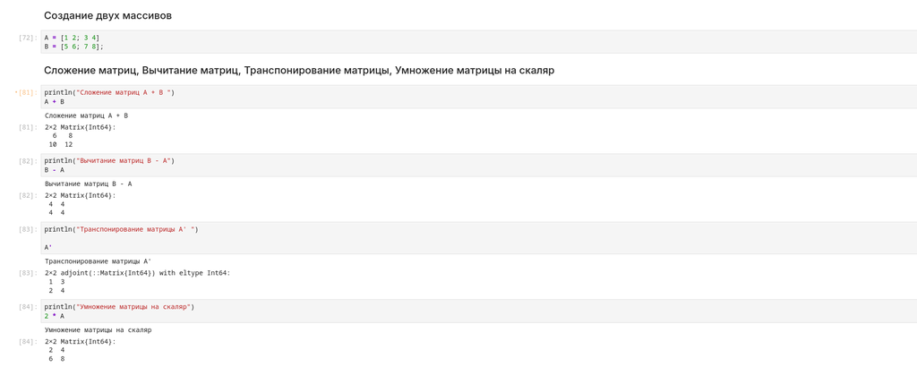

Рисунок 23: Выполнение основных операций над матрицами в Julia

# Заключение

- Настроена среда Julia и JupyterLab.
- Изучены основные типы данных.
- Рассмотрены функции чтения, записи и вывода информации.
- Исследована функция `parse()`.
- Выполнены арифметические, логические операции и операции сравнения.
- Рассмотрены способы создания функций.
- Выполнены основные операции с векторами и матрицами.